# RNA-seq数据及质量控制汇集

分子细胞科学卓越创新中心生物信息平台

2 June 2020

#### Abstract

本文描述了bulk RNA-seq分析流程中数据汇集子模块，该模块收集个样本质量控制及基因定量的信息，是后续差异表达分析、聚类、分类、功能富集分析的基础。该模块用R语言编写。

# 1 分析流程示意图

如下图所示，该模块汇集了两个方面的信息：质量控制和基因定量。质量控制主要来自于STAR比对及后续的RNASeQC分析，转录本定量来自Kallisto。

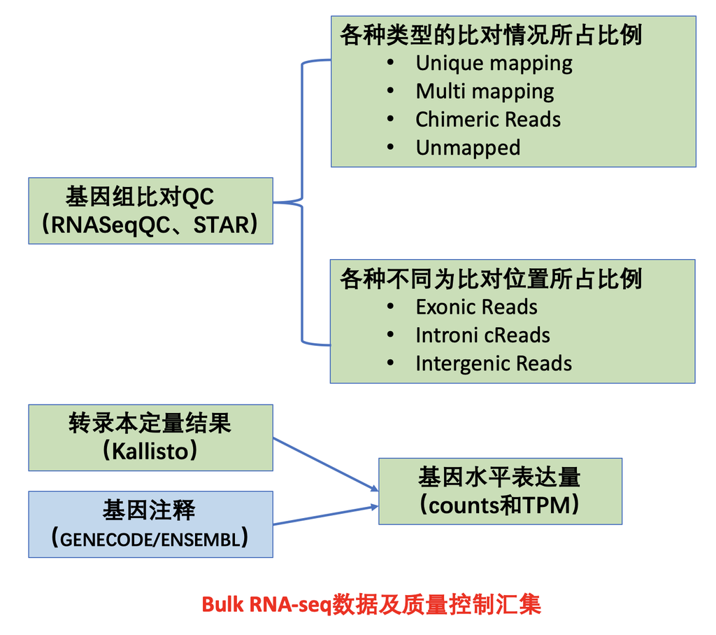

# 2 输出

## 2.1 质量控制

主要针对reads的比对情况做了统计，质量控制的信息以箱式图的形式展示，如下图所示。

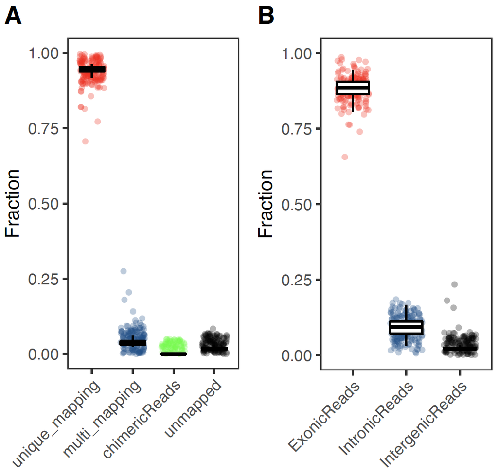

注：  
A图：  
unique_mapping：唯一比对的reads占总体reads的比例;  
multi_mapping：多重比对的reads占总体reads的比例；  
chimericReads：嵌合比对的reads占总体reads的比例;  
unmapped：未比对上参考基因组的reads占总体reads的比例。  
B图：  
ExonicReads：比对到基因外显子区域的reads占总体reads的比例;  
IntronicReads：比对到基因内含子区域的reads占总体reads 的比例；  
IntergenicReads：比对到基因间区的reads占总体reads的比例。

## 2.2 基因定量

将kallisto统计的转录本水平的定量结果转化为基因水平的结果，并且做了log2转换，基因ID包含 ENSEMBL和SYMBOL，文件内容如下所示：

```
"gene"  "Human.Cancer"
"ENSG00000000003.15 TSPAN6"     0.08281
"ENSG00000000005.6 TNMD"        0
"ENSG00000000419.12 DPM1"       4.622
"ENSG00000000457.14 SCYL3"      3.146
"ENSG00000000460.17 C1orf112"   3.249
```

注：  
gene：基因的ID，含ENSEMBL ID和SYMBOL，以空格分隔；  
Human.Cancer：基因表达量的TPM做log2转换后的值。

其他：更多详细的文件描述见FileDescription。